# Networks - day 3

2023-03-07

# Visualization

## The latent space model (LSM)

```r
LSM <- function(A,dim=2,...){
   # A is the adjacency matrix and is denoted by X in the maths,
   # dim is the dimensionality of the latent space (2 by default)
   n = nrow(A)

   # definition of the log-likelihood to optimize
   negloglik <- function(theta,A,dim){
      ll = 0
      alpha = theta[1]
      Z = matrix(theta[-1],ncol=dim)
      D = as.matrix(dist(Z))
      for (i in 1:(n-1)){
         for (j in (i+1):n){
            ll = ll + A[i,j]*(alpha - D[i,j]) - log(1 + exp(alpha - D[i,j]))
         }
      }
      negll = - 2 * ll
   }

   # Initial values for theta
   alpha_0 = 0.5
   Z_0 = rnorm(n*dim,0,1)
   theta = c(alpha_0,Z_0)

   # Numerical optimization
   theta_opt = optim(theta,negloglik,A=A,dim=dim,...)

   # Plot and return the results
   alpha = theta_opt$par[1]
   Z = matrix(theta_opt$par[-1],ncol=dim)
   return(list(alpha=alpha,Z=Z,Zinit=matrix(Z_0,ncol=dim),loss=theta_opt$value))
}
```

```r
library(sna)
```

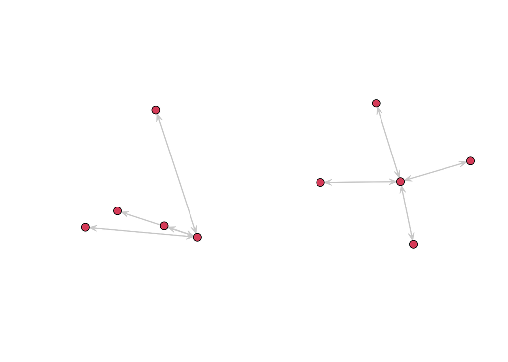

```r
X = rbind(c(0,1,1,1,1),
          c(1,0,0,0,0),
          c(1,0,0,0,0),
          c(1,0,0,0,0),
          c(1,0,0,0,0))

out = LSM(X,dim=2,method="SANN")
par(mfrow=c(1,2))
gplot(X,coord = out$Zinit,edge.col = "lightgray")
gplot(X,coord = out$Z,edge.col = "lightgray")
```

> Exercise: add som additional links in the adjacency matrix to see the effect (and possible limits) on the inference with LSM

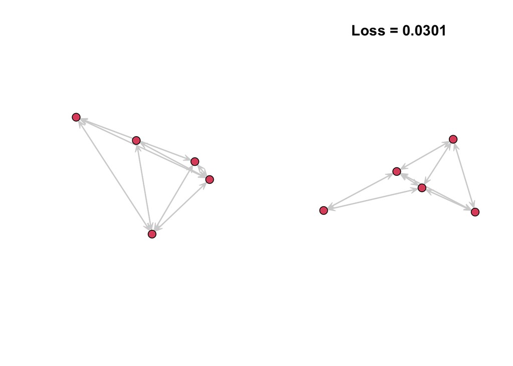

```r
X = rbind(c(0,1,1,1,1),
          c(1,0,1,1,0),
          c(1,1,0,1,0),
          c(1,1,1,0,1),
          c(1,0,0,1,0))

out = LSM(X,dim=2,method="SANN")
par(mfrow=c(1,2))
gplot(X,coord = out$Zinit,edge.col = "lightgray")
gplot(X,coord = out$Z,edge.col = "lightgray")
title(main = paste('Loss =',round(out$loss,4)))
```

Let’s now apply this method for visualizing the Sampson Monks network:

```r
X = read.csv(file = "~/Downloads/Sampson.csv")[,-1]
```

> Exercise: visualize the data with our LSM function.

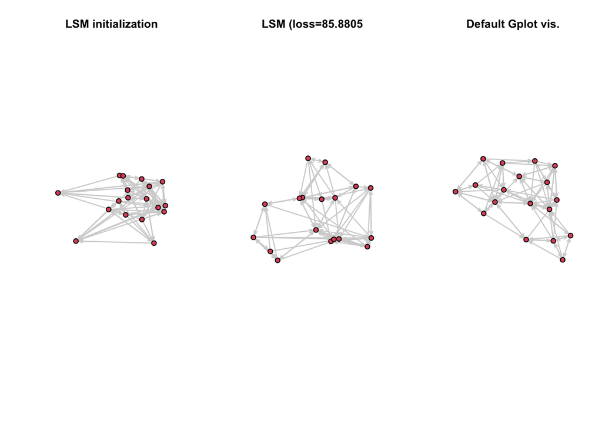

```r
out = LSM(X,dim=2,method="SANN")
par(mfrow=c(1,3))
gplot(X,coord = out$Zinit,edge.col = "lightgray")
title(main = 'LSM initialization')
gplot(X,coord = out$Z,edge.col = "lightgray")
title(main = paste('LSM (loss=',round(out$loss,4),sep=''))
gplot(X,edge.col = "lightgray")
title(main = "Default Gplot vis.")
```

In fact, it is also possible to use the Bayesian version of the LSM thanks to the `VBLPCM` package:

```r
#install.packages("VBLPCM")
library(VBLPCM)
```

> Exercise: use the package to visualize the Sampsan data within a 2-dimensional latent space.

```
## 1 / 50 iterations
## 2 / 50 iterations
## 3 / 50 iterations
## 4 / 50 iterations
## 5 / 50 iterations
## 6 / 50 iterations
## 7 / 50 iterations
## 8 / 50 iterations
## 9 / 50 iterations
## 10 / 50 iterations
## 11 / 50 iterations
## 12 / 50 iterations
## All converged after 13 iterations
## KL distance to true posterior is  -472.6629 + constant
```

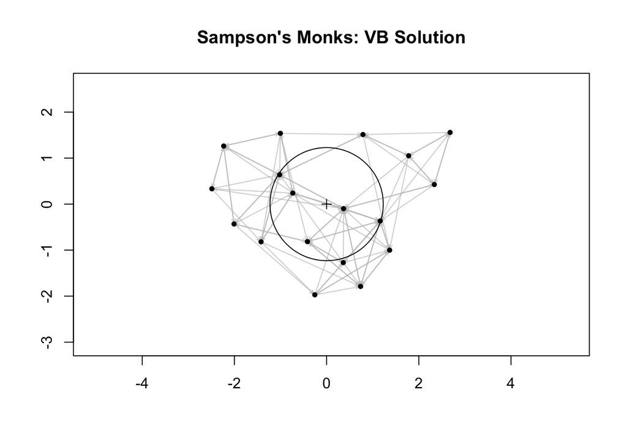

```r
library(network)
SampsonNet = as.network(as.matrix(X))
### plot the mean posterior positions with final estimations for variational parameters
plot(vblpcmfit(vblpcmstart(SampsonNet,G=1)),main="Sampson's Monks: VB Solution")
```

One of the most interesting feature of the latent space model is ability to evaluate the posterior probability of having an edge between two nodes ($P(X_{ij}=1|\hat\theta$).

To display this information, we of course have to compute those posterior probabilities for all pairs of nodes. Remembering that the model assumes:
$$\mathrm{logit}(P(X_{ij}=1|\theta)) = \alpha -
d(Z_i,Z_j),$$
and that $\mathrm{logit}(p) = \log(p/(1-p))$, compute the posterior probability $P(X_{ij}=1|\theta$. After some straightforward calculations, you should get:
$$P(X_{ij}=1|\theta) = \frac{\exp(\alpha -
d(Z_i,Z_j))}{1 + \exp(\alpha - d(Z_i,Z_j))}$$

> Exercise: code a small function `LSM.posterior` allowing to calculate those posterior probabilities once a LSM model has been fitted.

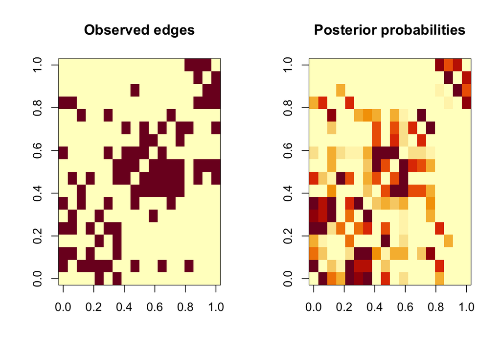

```r
LSM.posterior <- function(out){
  n = nrow(out$Z)
  D = as.matrix(dist(out$Z))
  P = matrix(0,n,n)
  for (i in 1:(n-1))
    for (j in (i+1):n)
      P[i,j] = P[j,i] = exp(out$alpha - D[i,j]) / (1 + exp(out$alpha - D[i,j]))
  return(P)
}

X = read.csv(file = "~/Downloads/Sampson.csv")[,-1]
out = LSM(X,dim=2,method="SANN")
P = LSM.posterior(out)

par(mfrow=c(1,2))
image(as.matrix(X),main="Observed edges")
image(P,main="Posterior probabilities")
```

Thanks to this map of posterior probabilities we can see relationships that may hidden in the data and revealed by the model.

## Multidimensional Scaling (MDS)

As discussed in the course, it is also possible to use the MDS method for visualizing a network. For this, we first need to compute the shortest-path distance between the nodes over the network. For that, we have to use the `igraph` library.

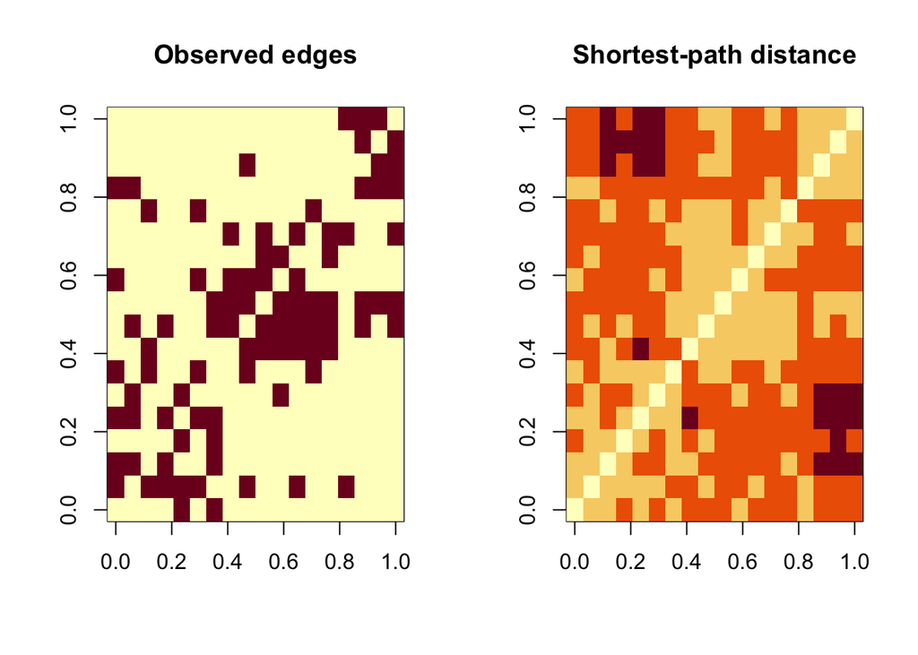

```r
#install.packages('igraph')
library(igraph)
X = read.csv(file = "~/Downloads/Sampson.csv")[,-1]
g = graph_from_adjacency_matrix(as.matrix(X))
D = shortest.paths(g)

par(mfrow=c(1,2))
image(as.matrix(X),main="Observed edges")
image(D,main="Shortest-path distance")
```

The MDS method is implemented in the function `cmdscale` in R.

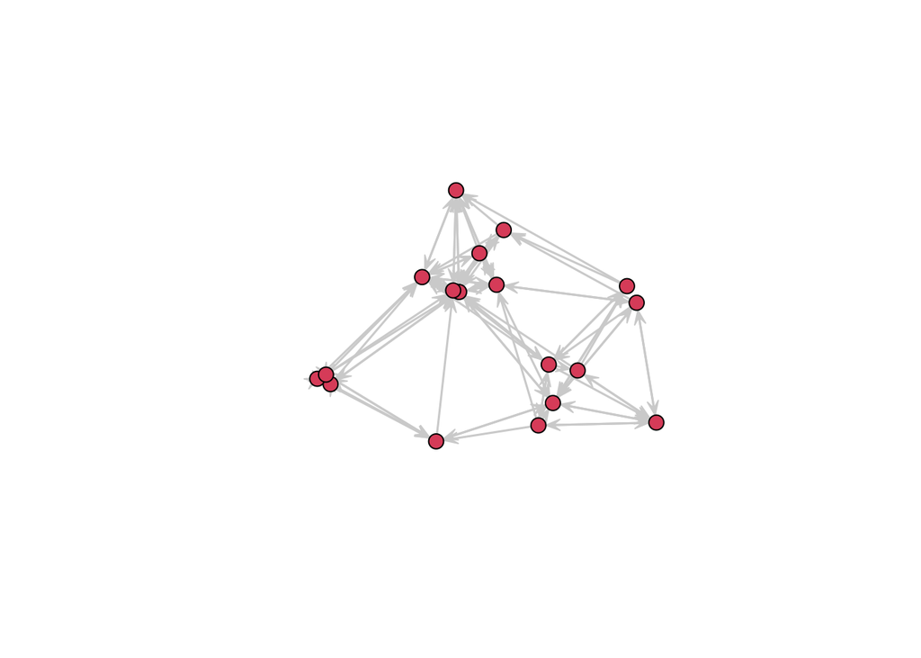

```r
out = cmdscale(D,k = 2)
gplot(X,coord = out,edge.col = "lightgray")
```

# Clustering of networks

## Latent Position Cluster Model (LPCM)

The LPCM model is the extension of the LSM model for clustering and visualization. It is implemented in two packages: `latentnet` (original one, MCMC algorithm) and `VBLPCM` (VBEM algorithm) packages.

```r
#install.packages("latentnet")
library(latentnet)
```

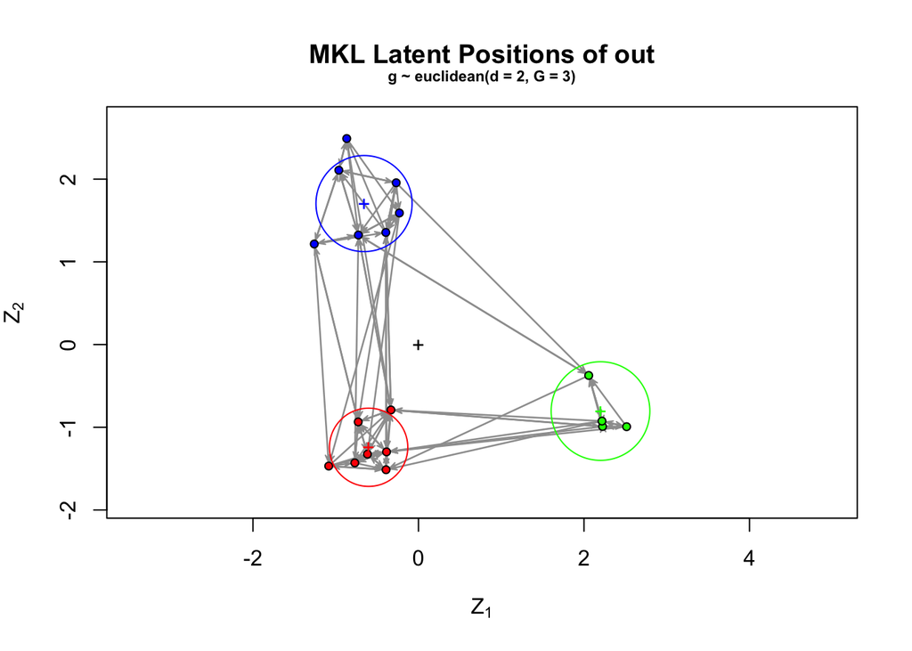

```r
library(network)
X = read.csv(file = "~/Downloads/Sampson.csv")[,-1]
g = as.network(as.matrix(X))

out = ergmm(g ~ euclidean(d = 2, G = 3))
plot(out)
```

On this example, we can clearly observe the effect of the Gaussian mixture prior on the visualization. The colors of the nodes also indicate the cluster memberships. The colored crosses and ellipses correspond to the fitted mixture parameters ($\mu_k$ and $\sigma_k^2$).

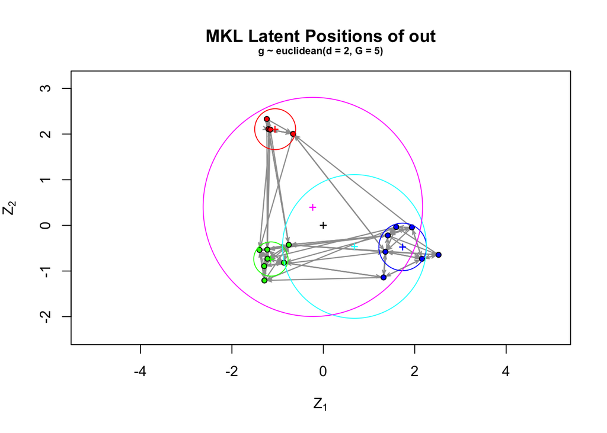

```r
out = ergmm(g ~ euclidean(d = 2, G = 5))
plot(out)
```

The alternative is to use the VBEM algorithm for inference, thanks to the VBLPCM package:

```r
out.vb = vblpcmfit(vblpcmstart(SampsonNet,G=3))
```

```
## 1 / 50 iterations
## 2 / 50 iterations
## 3 / 50 iterations
## 4 / 50 iterations
## 5 / 50 iterations
## 6 / 50 iterations
## 7 / 50 iterations
## 8 / 50 iterations
## 9 / 50 iterations
## 10 / 50 iterations
## 11 / 50 iterations
## 12 / 50 iterations
## 13 / 50 iterations
## All converged after 14 iterations
## KL distance to true posterior is  -458.1078 + constant
```

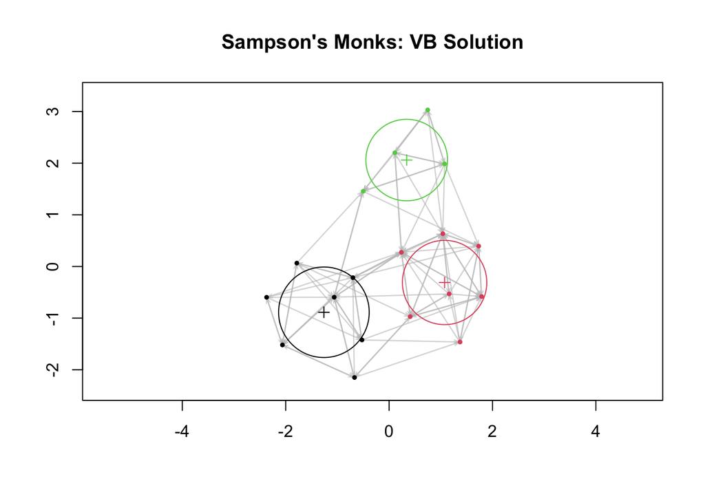

```r
plot(out.vb,main="Sampson's Monks: VB Solution")
```

We can oberserve that the visualization is perhaps slightly better, even though the clustering is the same.